# Mother to Child HIV Transmission and its socioeconomic context

Exploring Disparities, Trends, and Indicators

Author

Lakshay Joshi

Published

April 26, 2025

*Importing Libraries & Loading Data*

```python
#Importing Libraries & Loading Data
!pip install pandas plotnine geopandas quarto-cli pycountry polars openpyxl

import pandas as pd
import plotnine as p9
import geopandas as gpd
from plotnine import *
import pycountry

print(pd.__version__, p9.__version__, gpd.__version__,pycountry.__version__,)

df1 = pd.read_excel('Tableau Data .xlsx', sheet_name='Indicator 1 ')
df2 = pd.read_excel('Tableau Data .xlsx', sheet_name='Indicator 2 ')
df_meta = pd.read_excel('Tableau Data .xlsx', sheet_name='Metadata ')
```

*Explore & Cleaning data*

```python
# Display sample data for Indicator 1
df1.head(), df1.info(), df1.describe()

# Display sample data for Indicator 2
df2.head(), df2.info(), df2.describe()

# Display sample data for Metadata
df_meta.head(), df_meta.info(), df_meta.describe()

# Removing unnecessary spaces and rename for easier coding
df2.rename(columns={
    'country': 'Country',
    'HIV Transmission Rate (%)': 'HIV_Transmission',
    'Year': 'Year'
}, inplace=True)

df_meta.rename(columns={
    'Country Name': 'Country',
    'GDP per capita (constant 2015 US$)': 'GDP_per_Capita',
    'Life expectancy at birth, total (years)': 'Life_Expectancy',
    'Birth rate, crude (per 1,000 people)': 'Birth_Rate'
}, inplace=True)


print(df2.columns)
print(df_meta.columns)

# Merge datasets on BOTH "Country" and "Year"
combined = pd.merge(df2, df_meta, on=['Country', 'Year'], how='left')

# Check the result
combined.head()

# Checking if any important columns have missing values
combined.isnull().sum()

# Drop rows where important information is missing
combined.dropna(subset=['HIV_Transmission', 'GDP_per_Capita', 'Life_Expectancy', 'Birth_Rate'], inplace=True)

# Check the shape
combined.shape
```

*ready to create all visualizations*

```python
!pip install plotnine geopandas

from plotnine import *
import geopandas as gpd
import pandas as pd

# Load world map from an online GeoJSON file
world = gpd.read_file("https://raw.githubusercontent.com/datasets/geo-countries/master/data/countries.geojson")

print(world.columns)
print(combined.columns)

# Merge on country names
map_data = pd.merge(world, combined, left_on='name', right_on='Country', how='left')
```

# **# Global Situation: Mother to child HIV Transmission Rates**

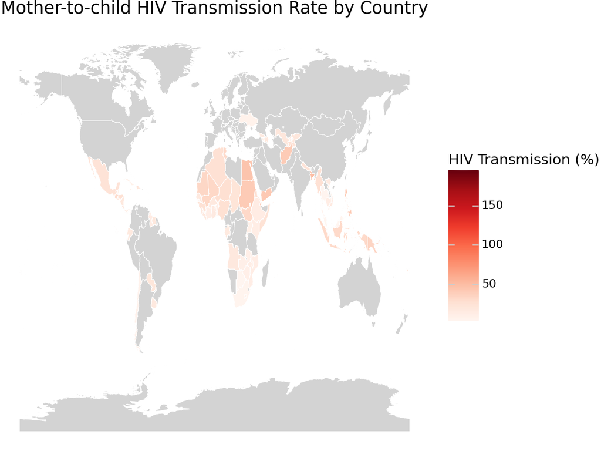

```python
#HIV rates by country
(ggplot(map_data) +
 aes(map_id='name', fill='HIV_Transmission') +  # map_id specified within aes()
 geom_map(color='white', size=0.2) +  # Removed map=map_data
 scale_fill_cmap(cmap_name='Reds', na_value='lightgrey') +
 theme_void() +
 labs(title='Mother-to-child HIV Transmission Rate by Country',
      fill='HIV Transmission (%)'))
```

```python
# Merge datasets on BOTH "Country" and "Year"
combined = pd.merge(df2, df_meta, on=['Country', 'Year'], how='left')

# Average HIV Transmission rate globally per year
hiv_time = combined.groupby('Year')['HIV_Transmission'].mean().reset_index()
```

# **Top 10 Countries with Highest Transmission**

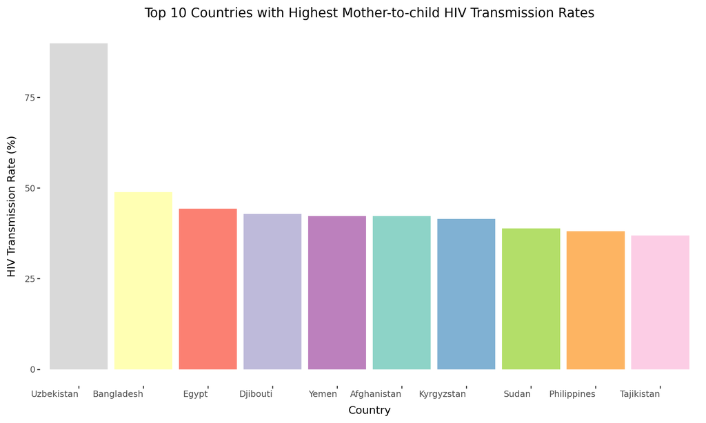

```python
#Top 10 counties with Highest mother to child HIV Transmission rate
(ggplot(top10_hiv) +
 aes(x='reorder(Country, -HIV_Transmission)', y='HIV_Transmission', fill='Country') +
 geom_col() +
 scale_fill_brewer(type='qual', palette='Set3') +   # <-- Add colorful palette
 labs(title='Top 10 Countries with Highest Mother-to-child HIV Transmission Rates',
      x='Country', y='HIV Transmission Rate (%)') +
 theme(
     axis_text_x=element_text(rotation=0, hjust=1),
     figure_size=(10,6),
     panel_background=element_rect(fill='white'),
     legend_position='none'
 ))
```

# **Global HIV Transmission Over Time**

The time series plot demonstrates a gradual decline in the average global Mother-to-child HIV transmission rates over the years. This trend suggests that global interventions — such as *improved prenatal screening, increased availability of antiretroviral treatments, and awareness campaigns — have been effective*. However, the pace of decline may vary significantly between regions, indicating that some countries still require targeted support and investment.

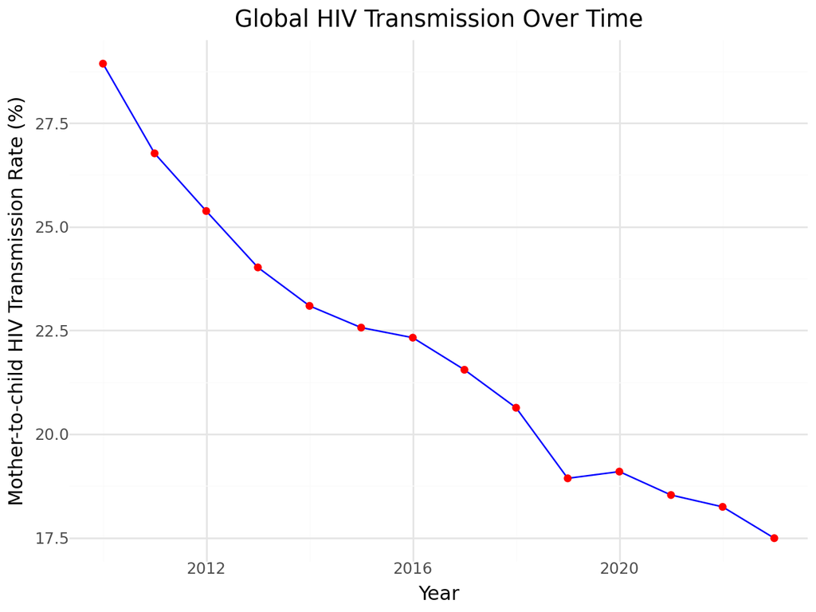

```python
#HIV rates changing globally over years
(ggplot(hiv_time) +
 aes(x='Year', y='HIV_Transmission') +
 geom_line(color='blue') +
 geom_point(color='red') +
 labs(title='Global HIV Transmission Over Time',
      x='Year', y='Mother-to-child HIV Transmission Rate (%)') +
 theme_minimal())
```